# A short XGBoost introduction

Christoph Kurz

August 31, 2015

## Installation

`Xgboost` is short for eXtreme Gradient Boosting and currently one of best machine learning packages available for R. It is [fast, memory efficient and can handle huge amounts of data](https://github.com/szilard/benchm-ml) and won several [kaggle competitions.](http://blog.kaggle.com/2015/08/26/avito-winners-interview-1st-place-owen-zhang/). `Xgboost` is now on CRAN and can be installed from there.

```r
library(xgboost)
```

## The data

As an example data set we use the `Adult` data from the `arules` package:

```r
library(arules)
data("AdultUCI")
```

We also load the `caret` package for the `createDataPartition()` function we use later.

```r
library(caret)
```

This data set is quite large, with over 48000 observations of 15 variables. Unfortunately it has a huge amount of missings, so we have to delete these oberservations. We delete all rows with missing values:

```r
data <- AdultUCI[complete.cases(AdultUCI),]
```

We still have 30162 observations left. The variable we want to predict is `income` which can take two states, *small* and *large*, so we are facing a binary classification problem.

## A simple prediction model

We split our `data` in a training and test set. `Xgboost` uses its own data structure called `xgb.DMatrix`. R’s `matrix` structure also works but `xgb.DMatrix` is preferred.

```r
set.seed(41)
idx <- createDataPartition(data$income, p = 0.85, list = FALSE, time = 1)
labels <- seq_along(levels(data$income))[data$income] - 1  # save the labels
data$income <- NULL                                        # now delete them
train <- model.matrix(~ . + 0, data[idx,])               # the training set
test <- model.matrix(~ . + 0, data[-idx,])               # the test set
dtrain <- xgb.DMatrix(data = train, label = labels[idx])
dtest <- xgb.DMatrix(data = test, label = labels[-idx])
```

We then set the `Xgboost` parameters, note that we set **auc** as the evaluation metric. `Xgboost` has some built-in evaluation metrics, this is also the reason why we specified the `label` parameter in `dtest`. Usually this information is not available for the test set and can be omitted. For evaluation we will later use the `ROCR` package, but we keep this for cosmetical reasons.

```r
param <- list(objective="binary:logistic", eta=0.01,
               min_child_weight=4, subsample=0.85, max_delta_step=3,
               colsample_bytree=0.3, max_depth=3, scale_pos_weight=1, eval_metric="auc")
num_rounds <- 5000
```

More information on these parameters can be found [here.](https://github.com/dmlc/xgboost/blob/master/doc/parameter.md)

Finally, we can train our model:

```r
mod <- xgb.train(params = param, data = dtrain, nrounds = num_rounds)
```

We then predict on the test set:

```r
pred <- predict(mod, dtest)
```

To evaluate the AUROC we use the package `ROCR`:

```r
library(ROCR)
```

```r
auc.tmp <- prediction(pred, labels[-idx])
auc <- performance(auc.tmp, "auc")
auc@y.values
```

```
## [[1]]
## [1] 0.9302011
```

We already get a pretty good AUC value of 0.9302011, here is the plot:

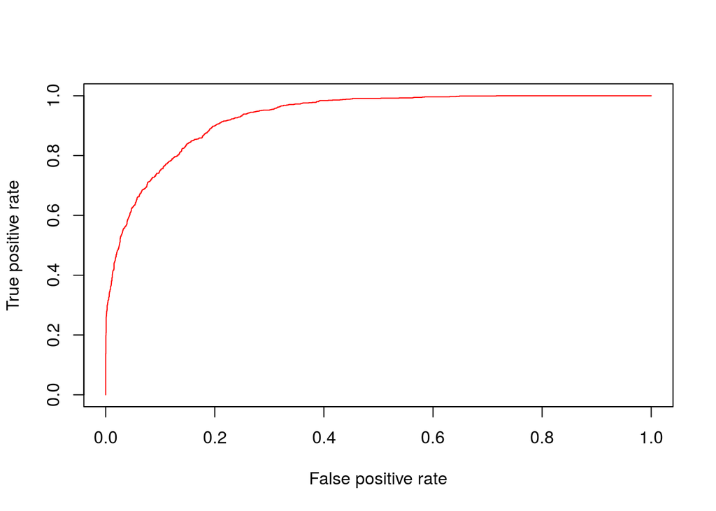

```r
auc <- performance(auc.tmp, "tpr", "fpr")
plot(auc,col=rainbow(10))
```

## A more advanced model

The main problem in boosting is when to stop the boosting iterations. Too many interations can lead to overfitting. `xgb.train` can follow the progress of the learning process after each round, so if we provide a second data set that is already classified, `Xgboost` can evaluate the model on this data and find the ideal stopping iterations.

To do this, we split the training data set again, in a new (smaller) training set and a validation set. Before, we had 25638 observations in our training set. We now use the first 2000 observations from this set for early stopping:

```r
valid <- train[1:2000,]
dvalid <- xgb.DMatrix(valid, label = labels[idx[1:2000]])
train2 <- train[-(1:2000),]
dtrain2 <- xgb.DMatrix(train2, label = labels[setdiff(idx, idx[1:2000])])
```

In addition, we have to specify a **watchlist**

```r
watchlist <- list("val"=dvalid, "train"=dtrain2)
```

Then we train the new model. Because of early stopping we can safely increase the number of boosting iterations:

```r
num_rounds <- 8000
mod2 <- xgb.train(param, dtrain2, nthread=2, nrounds = num_rounds, watchlist = watchlist,
                  early.stop.round = 200, maximize = TRUE)
```

We predict again:

```r
pred2 <- predict(mod2, dtest)
```

We compute the AUROC again:

```r
auc.tmp <- prediction(pred2, labels[-idx])
auc <- performance(auc.tmp, "auc")
auc@y.values
```

```
## [[1]]
## [1] 0.930055
```

We now get an AUC value of 0.930055. This is not an improvement, it is even slightly worse than our prediction from above. The reason for this may be because

1. the AUC is already very high. Remember, a perfect value would be 1.0, this is already close.
2. We lose some important information in the training set as we hold out 2000 observations for early stopping

```r
folds <- createFolds(labels[idx], k = 10)
fmat <- do.call(cbind, folds)
```

As a result, we get a list of length 10 that holds all the required indices of each fold. I converted the folds to a matrix `fmat` for easier indexing (because the observations cannot be divided by 10 evenly, some folds contain one repeated observation). Let’s build our 10 new training and validation sets:

```r
for(i in 1:10) {
  tr <- train[as.vector(fmat[,-i]),]
  v <- train[as.vector(fmat[,i]),]
  eval(parse(text=paste0("dval",i,"<-", "xgb.DMatrix(v, label = labels[idx[as.vector(fmat[,i])]])")))
  eval(parse(text=paste0("dtr",i,"<-", "xgb.DMatrix(tr, label = labels[idx[as.vector(fmat[,-i])]])")))
}
```

We have to build 10 watchlists, too:

```r
for(k in 1:10) {
  eval(parse(text=paste0("watchlist",k,"<-list('train'=dtr",k,",'val'=dval",k,")")))
}
```

Then, train all models:

```r
for(n in 1:10) {
  eval(parse(text=paste0("m",n,"<-xgb.train(param, dtr",n,",nthread=2, nrounds = num_rounds, watchlist = watchlist",n,",early.stop.round = 200, maximize = TRUE)")))
}
```

And predict on the test set:

```r
for(m in 1:10) {
  eval(parse(text=paste0("pr",m,"<-predict(m",m,",dtest)")))
}
```

Because we use AUC as our metric, we can just add up all predictions and then evaluate them again:

```r
finalpred <- pr1 + pr2 + pr3 + pr4 + pr5 + pr6 + pr7 + pr8 + pr9 + pr10
auc.tmp <- prediction(finalpred, labels[-idx])
auc <- performance(auc.tmp, "auc")
auc@y.values
```

```
## [[1]]
## [1] 0.9298569
```

We still could not improve, but I hope you get the idea. Be sure to check out `Xgboost`’s [github page](https://github.com/dmlc/xgboost) where you find more examples.